# KNN based Machine–Learning intro

23 August 2018

# Contents

**LAST UPDATE AT**

```
   [1] "Thu Aug 23 09:19:14 2018"
```

# 1 Preparations

We first set global chunk options and load the necessary packages.

```r
library("rmarkdown")
library("BiocStyle")
library("magrittr")
library("stringr")
library("ggthemes")
library("scales")
library("ggbeeswarm")
library("factoextra")
library("tidyverse")
library("readxl")
library("ggrepel")
library("RColorBrewer")
library("mlr")
library("psych")

set.seed(222)

theme_set(theme_bw(base_size = 18))
```

# 2 Introduction

In this tutorial, we will import data from a [high content screen](https://en.wikipedia.org/wiki/High-content_screening) performed on [HeLA](https://en.wikipedia.org/wiki/HeLa) cells in 96 well plates.

HeLA cells is a human cell line

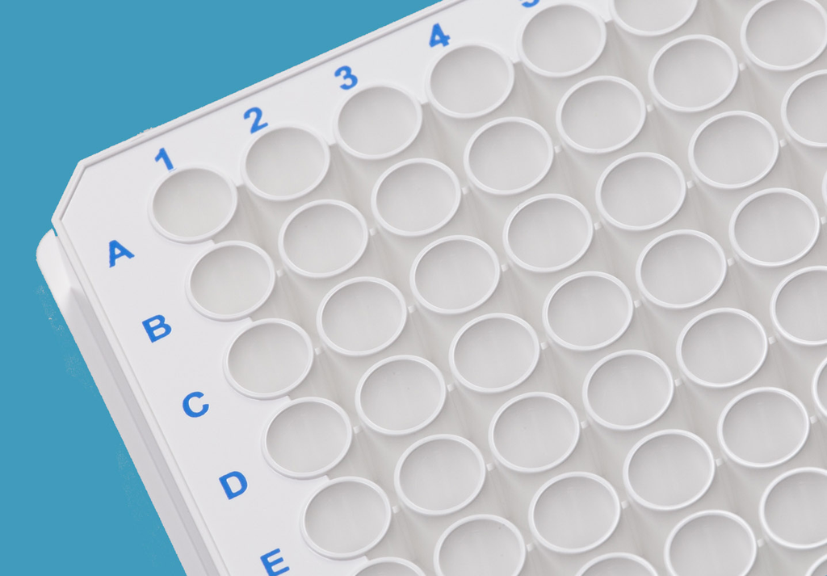

[siRNAs](https://en.wikipedia.org/wiki/Small_interfering_RNA) have been added to some of the wells in order to inhibit the activity of certain genes. The cells where then imaged over time and their (phenotype)[https://en.wikipedia.org/wiki/Phenotype] recorded.

The “phenotype” refers the the physical appearance of the cell as shown by the microscopy images. See Wikipedia on [phenotypic screening](https://en.wikipedia.org/wiki/Phenotypic_screening

The input data that we are going to use contains phenotypic class labels for each single cell. We want to use these class labels as features which in order to predict whether a well has been transfected with an siRNA or not.

These phenotypic classes of the single cells have been obtained using a machine learning algorithm based on the original image features. The data produced is similar to the one in Neumann et al. (2010): Each cell is classified into a mitotic phenotype class:

[Link to the Neumann et. al. paper](http://dx.doi.org/10.1038/nature08869)

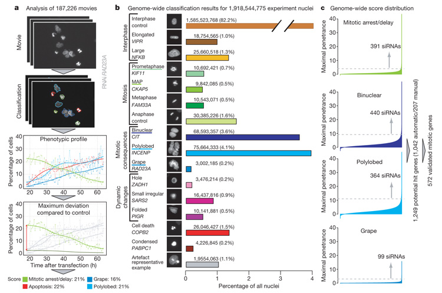

The siRNAs have used in the screen target genes that are known to be important in the regulation of [mitotis](https://en.wikipedia.org/wiki/Mitosis). Thus, “negative” wells and wells treated with siRNAs should show notably different phenotypes.

# 3 Data Processing

This part is might be interesting, but is not essential to understand for the machine learning part.

## 3.1 Annotation import

We first import the annotation of the plate. This consists of table that informs us about the content of each well on the plate. A well can be transfected with an siRNA targeting a certain gene, it can be empty, contain scrambled siRNAs or negative controls.

```r
plate_map <- read_excel("plate_mapping.xlsx")
plate_map
```

| Position | Well | Site | Row | Column | siRNA ID | Gene Symbol | Group |
| --- | --- | --- | --- | --- | --- | --- | --- |
| A01_01 | A01 | 1 | A | 1 | s7424 | INCENP | target |
| A02_01 | A02 | 1 | A | 2 | empty | NA | neg |
| A03_01 | A03 | 1 | A | 3 | empty | NA | neg |
| A04_01 | A04 | 1 | A | 4 | empty | NA | neg |
| A05_01 | A05 | 1 | A | 5 | s4445 | ECT2 | target |
| A06_01 | A06 | 1 | A | 6 | empty | NA | neg |
| A07_01 | A07 | 1 | A | 7 | empty | NA | neg |
| A08_01 | A08 | 1 | A | 8 | s449 | PLK1 | target |
| A09_01 | A09 | 1 | A | 9 | s444246 | XWNeg9 | neg |
| A10_01 | A10 | 1 | A | 10 | empty | NA | neg |

[output cut: 86 more lines]

## 3.2 Raw data import

We will now import the raw data. This data was originally stored in a variant of the [HDF5 format](https://en.wikipedia.org/wiki/Hierarchical_Data_Format) called [CellH5](http://www.cellh5.org/), which defines a more restricted sub–format designed specifically to store data from high content screens. More information can be found in the paper by Sommer et al. (2013).

Here, we import the data in convenient format: We have the data summarized across time points (via a sum of counts in the individual time points), where each column corresponds to a well and each row to a phenotypic class.

This is a typical example of a “wide” data table, where the variables contained in the data set spread across multiple columns.

```r
load("raw_data.RData")
```

## 3.3 Reshaping the screen data and joining the plate annotation

The result is a “long” data table, which contains one observation per row: in our case the number of times a cell was assigned to a specific class in every single well. Class in combination with well serves as our “key” here, and the class–count is the associated value.

We now want to join the annotation to this data table in the long format. Before we can do this, however, we need to solve a subtle problem: Our well identifiers in the imported data are different from the identifiers in the annotation table so we cannot easily join the two tables together.

We first need to strip the lead “W” from the well identifiers and replace the “P1” suffix by a “01” suffix. We do this by using a regular expression. Regular expressions are a powerful tool for the handling of strings and one can find a nice tutorial about them [here](http://www.zytrax.com/tech/web/regex.htm).

We can now join the annotation to our long table and use the well as the joining key.

```r
tidy_raw_data  <- rownames_to_column(as.data.frame(raw_data),
                                     var = "class") %>%
                  gather(key = "well", value = "count", -class)

tidy_raw_data
```

| class | well | count |
| --- | --- | --- |
| ana | WA01_P1 | 332 |
| apo | WA01_P1 | 5435 |
| artefact | WA01_P1 | 1059 |
| binuclear | WA01_P1 | 2604 |
| inter | WA01_P1 | 21865 |
| map | WA01_P1 | 2910 |
| meta | WA01_P1 | 238 |
| polylobed | WA01_P1 | 2726 |
| prometa | WA01_P1 | 2489 |
| telo | WA01_P1 | 1480 |

[output cut: 950 more lines]

```r
tidy_raw_data$well <- str_replace(tidy_raw_data$well, "^W([A-H][0-9]{2})_P1", "\\1_01")

#join annotation

input_data <- left_join(tidy_raw_data, plate_map, by = c("well" = "Position"))

input_data
```

| class | well | count | Well | Site | Row | Column | siRNA ID | Gene Symbol | Group |
| --- | --- | --- | --- | --- | --- | --- | --- | --- | --- |
| ana | A01_01 | 332 | A01 | 1 | A | 1 | s7424 | INCENP | target |
| apo | A01_01 | 5435 | A01 | 1 | A | 1 | s7424 | INCENP | target |
| artefact | A01_01 | 1059 | A01 | 1 | A | 1 | s7424 | INCENP | target |
| binuclear | A01_01 | 2604 | A01 | 1 | A | 1 | s7424 | INCENP | target |
| inter | A01_01 | 21865 | A01 | 1 | A | 1 | s7424 | INCENP | target |
| map | A01_01 | 2910 | A01 | 1 | A | 1 | s7424 | INCENP | target |
| meta | A01_01 | 238 | A01 | 1 | A | 1 | s7424 | INCENP | target |
| polylobed | A01_01 | 2726 | A01 | 1 | A | 1 | s7424 | INCENP | target |
| prometa | A01_01 | 2489 | A01 | 1 | A | 1 | s7424 | INCENP | target |
| telo | A01_01 | 1480 | A01 | 1 | A | 1 | s7424 | INCENP | target |

[output cut: 950 more lines]

## 3.4 Grouping, summarizing and data transformation

Before we can can continue with the data analysis, we have to make sure that the variables that we have obtained for every single well are normalized. As our data consists of the number of cells in each phenotypic category, a straightforward normalization consists of transforming the counts into percentages by dividing the data for each well by its total number of cells.

In the code chunk below, we use the `group_by()` function to partition the dataset into groups according to the well ID. We then apply the function `sum()` to the counts of each well and use `summarize()` to obtain a table of counts per well. This is an example of a **split–apply–combine** strategy.

We can now join the table containing the sums to the original data and compute compute percentage using the sums.

As Machine Learning and other techniques usually work best on data that is on normal distribution (z–score) scale, we perform a [logit](https://en.wikipedia.org/wiki/Logit) transformation to turn the percentages into z–scores. This is similar in spirit to a log transformation on intensity values.

```r
no_cells_per_well <- input_data %>%
                     group_by(well) %>%
                     dplyr::summarize(no_cells = sum(count))

no_cells_per_well
```

| well | no_cells |
| --- | --- |
| A01_01 | 41138 |
| A02_01 | 61821 |
| A03_01 | 37560 |
| A04_01 | 30438 |
| A05_01 | 19327 |
| A06_01 | 22986 |
| A07_01 | 28530 |
| A08_01 | 11995 |
| A09_01 | 23628 |
| A10_01 | 17515 |

[output cut: 86 more lines]

```r
data_with_sums <-  left_join(input_data, no_cells_per_well)
data_processed <- mutate(data_with_sums, perc = count / no_cells,
                       z_score = logit(perc))

data_processed
```

| class | well | count | Well | Site | Row | Column | siRNA ID | Gene Symbol | Group | no_cells | perc | z_score |
| --- | --- | --- | --- | --- | --- | --- | --- | --- | --- | --- | --- | --- |
| ana | A01_01 | 332 | A01 | 1 | A | 1 | s7424 | INCENP | target | 41138 | 0.0081 | -4.81 |
| apo | A01_01 | 5435 | A01 | 1 | A | 1 | s7424 | INCENP | target | 41138 | 0.1321 | -1.88 |
| artefact | A01_01 | 1059 | A01 | 1 | A | 1 | s7424 | INCENP | target | 41138 | 0.0257 | -3.63 |
| binuclear | A01_01 | 2604 | A01 | 1 | A | 1 | s7424 | INCENP | target | 41138 | 0.0633 | -2.69 |
| inter | A01_01 | 21865 | A01 | 1 | A | 1 | s7424 | INCENP | target | 41138 | 0.5315 | 0.13 |
| map | A01_01 | 2910 | A01 | 1 | A | 1 | s7424 | INCENP | target | 41138 | 0.0707 | -2.58 |
| meta | A01_01 | 238 | A01 | 1 | A | 1 | s7424 | INCENP | target | 41138 | 0.0058 | -5.15 |
| polylobed | A01_01 | 2726 | A01 | 1 | A | 1 | s7424 | INCENP | target | 41138 | 0.0663 | -2.65 |
| prometa | A01_01 | 2489 | A01 | 1 | A | 1 | s7424 | INCENP | target | 41138 | 0.0605 | -2.74 |
| telo | A01_01 | 1480 | A01 | 1 | A | 1 | s7424 | INCENP | target | 41138 | 0.0360 | -3.29 |

[output cut: 950 more lines]

Here, we use the chaining/piping operator `%>%` to “pipe” the result of a computation into the next. This leads to more digestible code compared to e.g. loops.

## 3.5 Input data after pre–processing

The input data contains the screen annotation as well as the [logit](https://en.wikipedia.org/wiki/Logit)–transformed class percentages per well (in the column `z-score`).

```r
data_processed
```

| class | well | count | Well | Site | Row | Column | siRNA ID | Gene Symbol | Group | no_cells | perc | z_score |
| --- | --- | --- | --- | --- | --- | --- | --- | --- | --- | --- | --- | --- |
| ana | A01_01 | 332 | A01 | 1 | A | 1 | s7424 | INCENP | target | 41138 | 0.0081 | -4.81 |
| apo | A01_01 | 5435 | A01 | 1 | A | 1 | s7424 | INCENP | target | 41138 | 0.1321 | -1.88 |
| artefact | A01_01 | 1059 | A01 | 1 | A | 1 | s7424 | INCENP | target | 41138 | 0.0257 | -3.63 |
| binuclear | A01_01 | 2604 | A01 | 1 | A | 1 | s7424 | INCENP | target | 41138 | 0.0633 | -2.69 |
| inter | A01_01 | 21865 | A01 | 1 | A | 1 | s7424 | INCENP | target | 41138 | 0.5315 | 0.13 |
| map | A01_01 | 2910 | A01 | 1 | A | 1 | s7424 | INCENP | target | 41138 | 0.0707 | -2.58 |
| meta | A01_01 | 238 | A01 | 1 | A | 1 | s7424 | INCENP | target | 41138 | 0.0058 | -5.15 |
| polylobed | A01_01 | 2726 | A01 | 1 | A | 1 | s7424 | INCENP | target | 41138 | 0.0663 | -2.65 |
| prometa | A01_01 | 2489 | A01 | 1 | A | 1 | s7424 | INCENP | target | 41138 | 0.0605 | -2.74 |
| telo | A01_01 | 1480 | A01 | 1 | A | 1 | s7424 | INCENP | target | 41138 | 0.0360 | -3.29 |

[output cut: 950 more lines]

The classes `ana` and `inter` are control categories of normally cycling cells, while the other classes correspond to abnormal phenotypes.

## 3.6 re–spreading and subsetting

We now spread the long table again and discard information not needed for ML so that we retain only the features and the target variable, i.e. the `Group` column.

```r
data_for_ML <- select(data_processed, class, Well, Group, z_score) %>%
               spread(class, z_score)
rownames(data_for_ML) <- data_for_ML$Well
data_for_ML$Group %<>% factor(levels = c("neg", "target"))
data_for_ML$Well <- NULL
```

# 4 The classification problem

The screen contains both wells with siRNAs that inhibit certain genes and wells that contain no / scrambled / negative control siRNAs. This is encoded in the variable `Group`.

We now want to see whether we can build a machine learning algorithm that will use the z–scores of the cell–classes as features in order to predict whether a well has been treated or not.

To get an idea, whether this is going to be successful, we take a look at the interphase z-scores. This is a control category, so the “negative” wells should have higher scores than the “target” ones.

```r
data_for_ML
```

|  | Group | ana | apo | artefact | binuclear | inter | map | meta | polylobed | prometa | telo |
| --- | --- | --- | --- | --- | --- | --- | --- | --- | --- | --- | --- |
| A01 | target | -4.8 | -1.88 | -3.6 | -2.7 | 0.13 | -2.6 | -5.1 | -2.6 | -2.7 | -3.3 |
| A02 | neg | -4.2 | -2.74 | -3.9 | -3.7 | 1.03 | -3.3 | -4.8 | -4.5 | -3.8 | -2.7 |
| A03 | neg | -4.0 | -2.68 | -4.7 | -4.0 | 1.22 | -3.7 | -4.7 | -4.6 | -3.6 | -3.0 |
| A04 | neg | -4.0 | -2.68 | -4.4 | -4.4 | 1.34 | -3.7 | -4.4 | -4.9 | -3.8 | -3.3 |
| A05 | target | -4.4 | -2.96 | -3.4 | -1.5 | 0.56 | -3.7 | -4.7 | -3.5 | -4.2 | -4.4 |
| A06 | neg | -3.8 | -2.38 | -4.6 | -4.6 | 1.21 | -3.8 | -4.4 | -6.2 | -3.4 | -3.3 |
| A07 | neg | -4.1 | -2.83 | -5.2 | -4.1 | 1.41 | -3.8 | -4.5 | -5.2 | -3.6 | -3.3 |
| A08 | target | -4.1 | -0.49 | -3.9 | -5.4 | -0.93 | -2.1 | -4.8 | -5.4 | -1.6 | -5.1 |
| A09 | neg | -3.9 | -2.13 | -3.7 | -4.3 | 1.11 | -3.4 | -4.6 | -5.5 | -3.9 | -4.1 |
| A10 | neg | -4.3 | -1.81 | -4.2 | -4.3 | 1.04 | -3.6 | -4.2 | -5.5 | -4.0 | -4.1 |

[output cut: 86 more lines]

[output not shown]

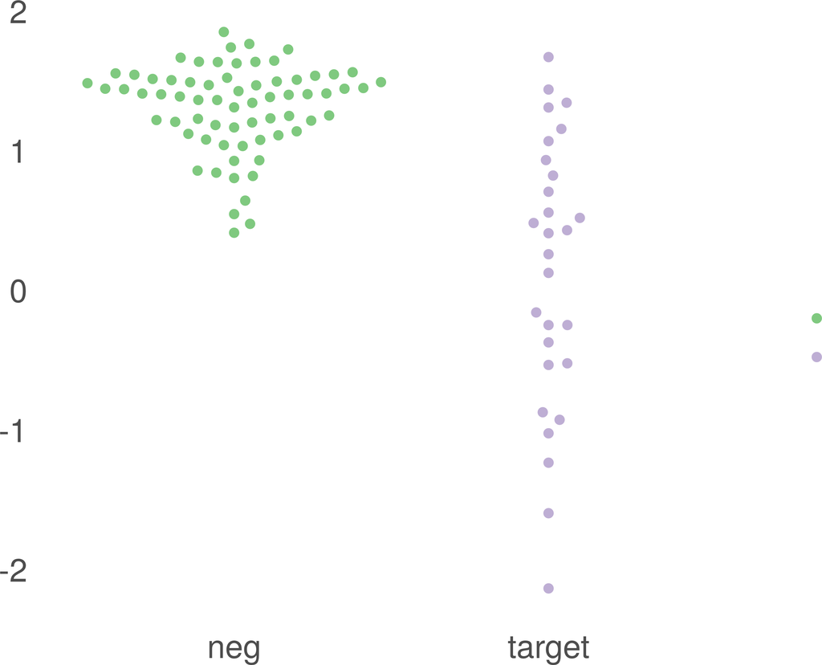

```r
ggplot(data = data_for_ML, aes(x = Group, y = inter, color = Group)) +
      geom_beeswarm(cex = 3) +
      ggtitle("Interphase z-scores") +
      scale_color_brewer(palette = "Accent")
```

Indeed, the negative wells have a higher “inter” score on average, thus “inter” should be an important feature in our classifier. The class–separation is further discussed in the “interlude” section below, where we reduce the dimensionality of the data.

# 5 Interlude: Principal Component Analysis

The data we have lives in a ten dimensional space, as every well contains cells classified into one of ten different classes. In order to produce a succinct overview of the data, one tries to reduce the dimensionality of the data. A popular way to do this is to compute new, artificial, variables that are a weighted sum of the original variables. The weights are obtained in such a way that the variables are independent of each other and retain as much of the original variability (a proxy of information content) as possible. These new variables are called “principal components” (PCs) of the data.

## 5.1 A PCA plot

We can use the function `prcomp()` to compute the principal components. We also create a vector `genes`, giving us the gene each of our siRNAs is targeting.

We then create a ggplot object by mapping the first principal component to the x– and the second one to the y–axis. We use the gene names as plotting symbols and color the names according to to the gene name (We have multiple empty wells as well as multiple siRNAs targeting the same gene).

Furthermore, we specify that the aspect ratio of x and y axis should be equal to the ratio of the standard deviation of PC1 to the standard deviation of PC2 so that the axes represent the same units. This facilitates a correct interpretation of the PCA plot: PC1 has more variance than PC2, so the x–axis should be longer than the y–axis to reflect the differences in scale.

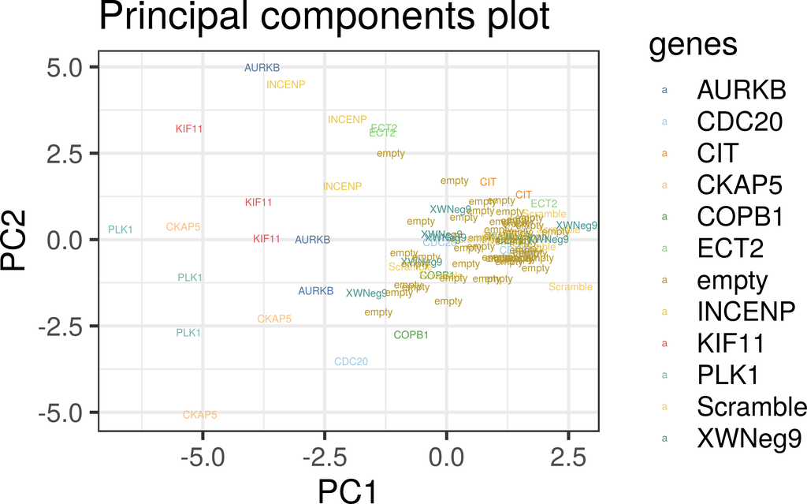

Figure 1: PCA plot

```r
data_for_PCA <- data_processed %>%
                dplyr::select(class, well, z_score) %>%
                spread(key = class, value = z_score)

PCA <- prcomp(data_for_PCA[, -1], center = TRUE, scale. = TRUE)


genes <- input_data %>%
         group_by(well) %>%
          dplyr::summarize(gene = unique(`Gene Symbol`))

genes <- ifelse(is.na(genes$gene), "empty", genes$gene)

dataGG = data.frame(PC1 = PCA$x[,1], PC2 = PCA$x[,2],
                    PC3 = PCA$x[,3], PC4 = PCA$x[,4],
                    genes)

pl <- (ggplot(dataGG, aes(x = PC1, y = PC2, color =  genes))
      + geom_text(aes(label = genes), size = I(2))
      + coord_fixed(ratio = (PCA$sdev)[2] / (PCA$sdev)[1])
      + ggtitle("Principal components plot")
      )

pl + scale_color_tableau(palette = "Tableau 20")
```

We can see, for example, that the control wells cluster together. Note that it is easy to turn this plot into an interactive version using `ggplotly` from the *plotly*.

```r
if(!("plotly" %in% installed.packages()[,1])){
  install.packages("plotly")
}

library(plotly)
ggplotly(pl)
```

[output not shown]

## 5.2 Variable importance for the principal components

The first PC nicely separates wells containing various controls from the ones treated with siRNAs. As every component is simply a weighted sum of the original variables, we can inspect these weights (called “loadings”) to see which classes “drive” the components and try to interpret what we find.

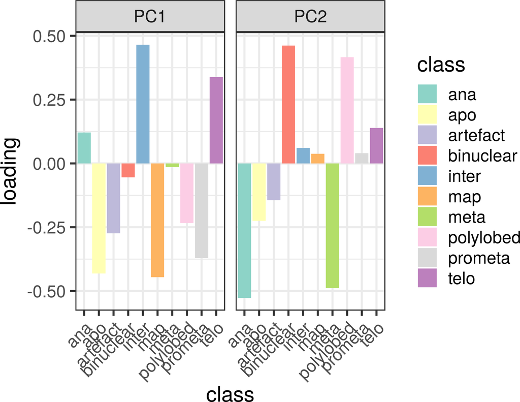

```r
loadings <- PCA$rotation[, 1:2]
loadings_gg <- loadings %>%
               as.data.frame() %>%
               rownames_to_column(var = "class") %>%
               dplyr::select(class, PC1, PC2) %>%
               gather( key = "comp", value = "loading", PC1:PC2)

ggplot(loadings_gg, aes(x = class, y = loading, fill = class)) +
      facet_wrap( ~ comp) +
      geom_bar(stat = "identity", position = "identity") +
      theme(axis.text.x = element_text(angle = 45, hjust = 1)) +
      scale_fill_brewer(type = "qual", palette = "Set3")
```

We can see that e.g. the “inter” and the “map/prometa” classes as well as the “apo” class are important for PC1. The map and prometa classes combined define cells that are in mitotic delay/arrest, while the interphase class defines a control category.

So a possible explanation for PC1 would be that it separates wells with cells in mitotic arrest/delay (or apoptotic cells) from control wells with many cells in the interphase phase (c.f. Figure 1 of Neumann et al. (2010)).

The second principal component seems to separate wells that contain mainly cells in ana–/metaphase from wells that predominantly contains cells with strange shape phenotypes.

## 5.3 Correlation circles and PCs for hit calling

The loadings are closely related (up to a scaling factor) to the correlation of the original variables with the computed principal components. We can investigate this relationship by plotting the correlations of the original variables with the components in a circle.

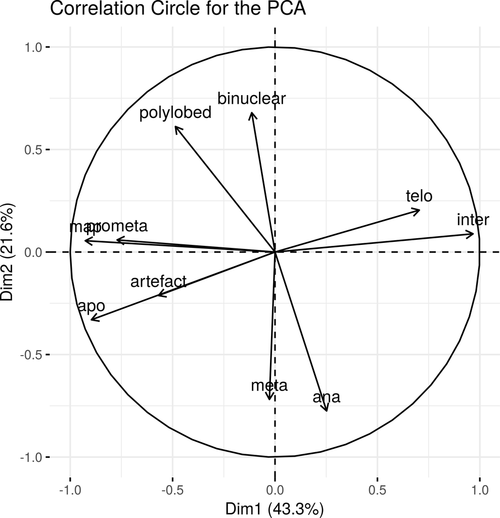

Figure 2: Correlation Circle

```r
fviz_pca_var(PCA, col.circle = "black",
             title = "Correlation Circle for the PCA") +
              coord_equal()
```

PC2 is positively correlated with the strange phenotypes. Thus, we could potentially use the first and second PC to call hits. For example, PLK1, which is very far from the controls in PC1 coordinates is known to be important during the M–phase of the cell cycle. Thus, if this gene is inhibited, the mitosis does not work properly any more and the cells are stuck in the cell cycle or undergo apoptosis.

# 6 Building a knn classifier.

We use k–nearest–neighbors or knn for short, which predicts the class of a well by considering the k–nearest wells as measured by the Euclidean distance on the features (phenotype classes). The class of a well is then given by the majority–vote of the neighbors.

[Description of the knn algorithm on Wikipedia](https://en.wikipedia.org/wiki/K-nearest_neighbors_algorithm#Algorithm)

knn is useful especially for relatively low–dimensional data, as it conceptually simple and fully non–parametric: It’s decision boundaries can have arbitrary shapes.

However, in high–dimensional data, it can be hard to have an appropriate number of neighbors for each sample, and knn might thus not perform very well in these settings.

We can use the *mlr*–function `listLearner()` to find R functions implementing knn. We use the function `knn` from the package `class`. In *mlr* this function is wrapped as `classif.knn`.

```r
cl_task <- makeClassifTask(id = "HTScreen", data = data_for_ML,
                           target = "Group", positive = "target")
cl_task
```

```
   Supervised task: HTScreen
   Type: classif
   Target: Group
   Observations: 96
   Features:
      numerics     factors     ordered functionals
            10           0           0           0
   Missings: FALSE
   Has weights: FALSE
   Has blocking: FALSE
   Has coordinates: FALSE
   Classes: 2
      neg target
       68     28
   Positive class: target
```

```r
all_cl <- listLearners("classif")
filter(all_cl, str_detect("knn", all_cl$short.name))
```

| class | name | short.name | package | note | type | installed | numerics | factors | ordered | missings | weights | prob | oneclass | twoclass | multiclass | class.weights | featimp | oobpreds | functionals | single.functional | se | lcens | rcens | icens |
| --- | --- | --- | --- | --- | --- | --- | --- | --- | --- | --- | --- | --- | --- | --- | --- | --- | --- | --- | --- | --- | --- | --- | --- | --- |
| classif.knn | k-Nearest Neighbor | knn | class |  | classif | TRUE | TRUE | FALSE | FALSE | FALSE | FALSE | FALSE | FALSE | TRUE | TRUE | FALSE | FALSE | FALSE | FALSE | FALSE | FALSE | FALSE | FALSE | FALSE |

## 6.1 Define the learner and set the hyperparameters

Before we can use the knn–classifier, we need to choose the number of neighbors to consider. Here, we simply fix this at 5 neighbors. In practice this is a tuning parameter that would be optimized based on e.g. a grid of neighbor–values (from 3 to 10 say) and resampling based methods like nested cross–validation.

Large values of k reduce the noise but result in a less adaptive algorithm.

See the classic [paper by Ambroise and MacLachlan](http://www.pnas.org/content/99/10/6562.short) for a discussion and examples of suboptimal parameter selection strategies in gene expression data.

We use the *mlr*–function `makeLearner` in order to create the classifier.

```r
lrn <- makeLearner("classif.knn", k = 5)
print(lrn)
```

```
   Learner classif.knn from package class
   Type: classif
   Name: k-Nearest Neighbor; Short name: knn
   Class: classif.knn
   Properties: twoclass,multiclass,numerics
   Predict-Type: response
   Hyperparameters: k=5
```

```r
getHyperPars(lrn)
```

```
   $k
   [1] 5
```

## 6.2 Train and evaluate the classifier

We are now ready to train the classifier. For this we perform a simple train–test split: We use 80% of the data (77 wells) for training and evaluate the classifier on the rest.

Not that it is very important to perform these splits, as evaluation an ML algorithm on the data it was trained on leads to overoptimistic results.

This is also true for selecting the tuning parameters, see the note in section 6.1

```r
n <- getTaskSize(cl_task)

train_set <- sample(n, size = round(n * 0.8))
head(train_set)
```

```
   [1] 28 75 39 83 87  5
```

```r
screen_knn <- train(lrn, cl_task, subset = train_set)
screen_knn
```

```
   Model for learner.id=classif.knn; learner.class=classif.knn
   Trained on: task.id = HTScreen; obs = 77; features = 10
   Hyperparameters: k=5
```

```r
test_set <- setdiff(seq_len(n), train_set)
pred <- predict(screen_knn, task = cl_task, subset = test_set)

pred
```

```
   Prediction: 19 observations
   predict.type: response
   threshold:
   time: 0.00
       id  truth response
   A07  7    neg      neg
   B03 15 target      neg
   B05 17    neg      neg
   B09 21 target      neg
   B10 22 target   target
   C05 29 target      neg
   ... (#rows: 19, #cols: 3)
```

```r
performance(pred)
```

```
   mmce
   0.26
```

Running the function `predict` returns the predictions of the knn classifier. Furthermore we compute the mean misclassification error, which is the proportion of misclassified wells in our test dataset. This is 0.26, which is reasonably low.

## 6.3 Confusion matrix

The mean misclassification error is an average, however, it is also interesting to check the class–specific error rates, i.e. how many “positives” / “negatives” (target / negative wells) we predict correctly.

This can be seen in the so–called confusion matrix.

```r
calculateConfusionMatrix(pred = pred)
```

```
           predicted
   true     neg target -err.-
     neg     11      0      0
     target   5      3      5
     -err.-   5      0      5
```

We immediately see that we make more mistakes within the positive (target) than within the negative class. As the PCA plot shows, there are some target wells that cluster with the negative ones, those are obviously hard to predict via a nearest–neighbor technique.

## 6.4 Vizualization of the prediction algorithm

*mlr* has built–in functionality to visualize a classifier in two–dimensions. Here, we select two feature, “ana” and “inter” which we suspect in being important to discriminate between target and negative wells and train a our knn classifier only on them.

The function `plotLearnerPrediction` then visualizes the prediction boundary.

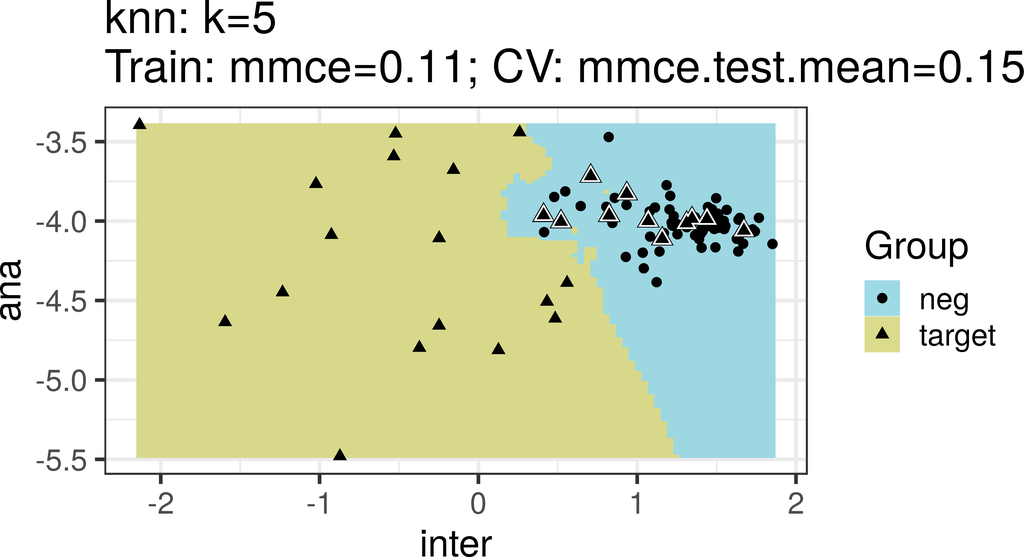

Figure 3: Vizualization of the KNN decision Boundary

```r
learn_pl <- plotLearnerPrediction(learner = lrn, task = cl_task,
                      features = c("inter", "ana"), cv = 5) +
  scale_fill_tableau(palette = "Classic 10 Light") +
  geom_tile(alpha = 0.01) +
  coord_fixed()

learn_pl
```

Indeed, the two features separate our two groups fairly well but there are some target wells that cluster together with the negative ones. This plot is quite similar to the PCA plot (Figure 1). This is unsurprsing since our two features are highly correlated to the the fist two PCs..

See the correlation circle in Figure 2

These might be wells where the siRNAs or the experiment simply did not work. (The data is the result of an experiment performed by course participants who performed such a screen for the very first time).

[output not shown]

# References

Neumann, Beate, Thomas Walter, Jean-Karim H’eric ’e, Jutta Bulkescher, Holger Erfle, Christian Conrad, Phill Rogers, et al. 2010. “Phenotypic Profiling of the Human Genome by Time-Lapse Microscopy Reveals Cell Division Genes.” *Nature* 464 (7289). Springer Nature: 721–27. doi:10.1038/nature08869.

Sommer, C., M. Held, B. Fischer, W. Huber, and D. W. Gerlich. 2013. “CellH5: A Format for Data Exchange in High-Content Screening.” *Bioinformatics* 29 (12). Oxford University Press (OUP): 1580–2. doi:10.1093/bioinformatics/btt175.